# Bioacoustics: Using Species Classifiers in R

Bioacoustics: Using Species Classifiers in R James E Paterson 2025-12-29

[figure not shown]

Many of the applications of bioacoustics require identifying which species are vocalizing in a sound clip. For example, answering questions about species richness, a species’ or community’s responses to environmental variation, or monitoring changes in communities through time. The advent of long, continuous recordings from Autonomous Recording Units vastly increased the amount of data available to answer questions about bioacoustics, but also created a challenge in how to efficiently process the information and use it for inference.

Multi-species classifiers, which predict classes (e.g., species) within sound clips, offer a way to automate parts of the process. Many multi-species classifiers are available, but to demonstrate their application, I will use BirdNet in this tutorial.

In this tutorial, I cover the basics of species classifiers in R. We’ll use the `tuneR`, `monitoR`, and `birdnetR` packages.

Let’s get started.

## Species Classifiers

In the last 10 years, many multi-species classifiers have been developed for use or re-training by researchers. Sound classifiers work by using spectrograms (images) to train models with labelled data. They have been applied to many different scenarios, including identifying species, individual animals, types of vocalizations made by the same species, non-biotic sounds, and more. The most common application is to identify species. The types of models have changed through time, with current large-scale classifiers with many classes (i.e., those that classify many species) typically built with neural networks.

[BirdNet](https://github.com/birdnet-team/BirdNET-Analyzer) is probably the most widely used classifier and currently has more than 6000 species classes. BirdNet has inspired other regional tools, such as HawkEars for Canadian birds and amphibians. Below, we’ll use BirdNet, because the workflow is well-developed, its application is instructive for using other multi-species classifiers, and it is available directly in R through a connection package, `birdnetR`.

To get started, we’ll load the `birdnetR` package, initialize the classifier model, and load an example soundscape file I recorded at Oak Hammock Marsh in Manitoba, Canada.

```r
# Load Library
library(birdnetR)
library(tuneR)

# Load recordings (.wav) using tuneR::readWave
marshSounds2 <- tuneR::readWave("marshSounds_2025-06-02_1148.wav")

# Initialize the TFLite BirdNet Model
# This will take some time the first time you run it
# Read more about initializing different versions of birdnet: https://birdnet-team.github.io/birdnetR/articles/birdnetR.html
birdnet_model <- birdnet_model_tflite("v2.4")

# File path to audio file
audio_path_marshSounds2 <- file.path(getwd(), "/marshSounds_2025-06-02_1148.wav")

# Predict species in the audio file
predictions_marshSounds2 <- predict_species_from_audio_file(birdnet_model, # initialized BirdNet model
                                                            audio_path_marshSounds2, # path to audio file
                                                            min_confidence = 0.1, # the minimum BirdNet confidence to report
                                                            chunk_overlap_s = 2.5, # BirdNet works on 3s chunks, here I use 2.5s overlap between 3s chunks
                                                            keep_empty = FALSE)

# Print predictions table
head(predictions_marshSounds2)
```

```
##   start end    scientific_name         common_name confidence
## 1   1.0 4.0 Geothlypis trichas Common Yellowthroat  0.1508066
## 2   1.5 4.5 Geothlypis trichas Common Yellowthroat  0.1664470
## 3   2.0 5.0 Geothlypis trichas Common Yellowthroat  0.1757127
## 4   2.5 5.5 Geothlypis trichas Common Yellowthroat  0.1336502
## 5   3.0 6.0 Geothlypis trichas Common Yellowthroat  0.1063256
## 6   6.0 9.0  Tyrannus tyrannus    Eastern Kingbird  0.1217506
```

From the data.frame, we see:

- there is a row for every detection, and values for start and end (in seconds), scientific name, common name, and confidence (0 - 1).
- there are detections for species that don’t occur in Canada (e.g., Jungle Prinia, Eastern Clapper Lark)
- there are sometimes multiple species predicted in the same 3 s chunk. You can adjust the predictions to only choose the most-likely species per 3 s time chunk with `get_top_prediction()`, but in many cases we expect vocalizations to have considerable overlap. For example, if birds of multiple species are calling at the same time.

Since we used a chunk overlap of 2.5s, there are multiple detections of the same vocalization (e.g., Common Yellowthroat starting at 1s, 1.5s, 2s, etc.). Increasing the chunk overlap takes more processing time, but can help increase detection of species. For example, if a species vocalizes from the 2nd to 4th second of a clip analyzed with no chunk overlap, then it would be partially covered in the 0-3 s chunk and the 3-6s chunk. Since the vocalization is clipped in both chunks, it may not be detected. However, if the overlap is increased (e.g., to 2s), then the whole vocalization would be captured in the 1-4s chunk and in the 2-5s chunk.

By listening to the sound clip, we observe:

- BirdNet was good at identifying the species (and mostly the timing) of species with clear vocalizations (i.e., closest to the microphone), including Bobolink, Swamp Sparrow, and Savannah Sparrow.
- There are several other species’ vocalizations that are rather obvious to a human listener that were not included (even with low confidence). For example, there are several clear vocalizations in the clip of: Red-winged Blackbird and Yellow Warbler.
- Some species are correctly identified, but with low confidence (e.g., < 0.20). Whereas, other species identifications at similar confidence levels are not correct.

Like many parts of bioacoustic workflows, you can get stuck in analysis-paralysis because of how much information is available and how ambiguous it can be.

Here’s some practical advice:

- Using species-classifiers can help reduce the need for humans to listen to *every* minute of available recordings.
- Species-classifiers will miss lots of vocalizations that human listeners could identify and will also have false positive observations.
- One of the biggest benefits of an approach with species-classifiers is that the detection window can be much longer than human surveys. You’ll miss some species’ detections with passive monitoring that uses species-classifiers, but if you record long enough, the bird (or other species) will likely be close enough to the microphone or the conditions will be more favourable for detection later.
- Some form of expert verification and data cleaning is required. For example, I typically will use a workflow to verify each species detected at each site.

Now that BirdNet has grown greatly in the number of classes (species), it frequently will identify species that are not in your study area (or at least highly unlikely). You can use lists of species based on your research goals or based on geography to reduce the prediction table.

Below, I will remove species unlikely to occur at the recording location during the week of the year from the recording using the `predict_species_at_location_and_time()` function. It uses BirdNet’s Species Range Model based on eBird checklist frequency data to estimate the probability of bird species occurrences based on location and week of the year. I use a conservative bound (minimum confidence of 0.01) to still include species that occur infrequently (e.g., range edge).

```r
test_birdnet_model <- birdnet_model_meta()
marshSounds2LikelySpecies <- predict_species_at_location_and_time(test_birdnet_model, # a meta version of the model
                                                                  latitude = 50.174801, # I chose the lat and long based on where I recorded
                                                                  longitude = -97.135426,
                                                                  # Integer for week of the year, leaving it blank would produce an annual list
                                                                  week = lubridate::week(as.Date("2025-06-02")),
                                                                  # for min_confidence, the default = 0.03, which might remove uncommon species
                                                                  min_confidence = 0.01) |>
  # I split the label (scientific name and common name) to be able to filter by common_name
  dplyr::mutate(common_name = stringr::str_split(label,
                                          pattern = "_",
                                          simplify = TRUE)[,2])

# Filter
predictions_marshSounds2_filtered <- predictions_marshSounds2 |>
  dplyr::filter(common_name %in% marshSounds2LikelySpecies$common_name)
```

Limiting the predictions to species that have been reported in Manitoba (the province the recording is from) reduces the number of detections from 181 to 152. For some study areas and recordings, this step makes a big difference because there may be similar sounding species from very different parts of the world. For example, I have observed many Sedge Wren (*Cistothorus stellaris*) vocalizations identified as Grass Wren (*C. platensis*) in recordings from Prairie Canada. Sedge Wrens breed in Canada, whereas Grass Wrens breed in Central and South America; they used to be considered one species and were split using genetic evidence, as well as bevhavioural differences in migration and vocalization. Removing species that do not occur in a study area can greatly improve efficiency of processing classifier predictions, but remember that filtering species may remove legitimate observations because they are unlikely.

So what next? Let’s use the output of our filtered species detection table to isolate, display, and save a clip of each predicted species’ vocalization. This workflow is useful for having human listeners verify observations.

```r
# Hold Wave class objects of clips in a list. This is inefficient for large recordings or many files.
# For scaling, I suggest writing clips directly to .wave files, and included code to do that.
detection_clip_list <- list()

# For tracking clip names, you can add a vector in the prediction dataframe birdnetR created
predictions_marshSounds2_filtered$clip_name <- NA

# For each detection from birdnetR...
for(i in 1: nrow(predictions_marshSounds2_filtered)){
# Save just that part of the clip
detection_i_name <- paste0("marshSounds_2025-06-02_1148", "_",
                           predictions_marshSounds2_filtered$common_name[i], "_",
                           predictions_marshSounds2_filtered$start[i], "s")

# Read in just the 3s detection with a 3s buffer on either side.
detection_i_wave <- tuneR::readWave("marshSounds_2025-06-02_1148.wav",
                                    from = predictions_marshSounds2_filtered$start[i]-3,
                                    # from = ifelse(predictions_marshSounds1$start[i]-4 < 1,
                                    #               1,
                                    #               predictions_marshSounds1$start[i]-4),
                                    units = "seconds",
                                    to = predictions_marshSounds2_filtered$end[i]+3)

detection_clip_list[[i]] <- detection_i_wave
names(detection_clip_list)[i] <- detection_i_name

# Not run, but we could save every clip to be used for human listening verification outside R, keeping original file name and the predicted species
# writeWave(object = detection_i_wave,
#           # Could put in an output folder or structure clips by site or species, depending on objectives
#           filename = detection_i_name)

# Add details to predictions_marshSounds2
predictions_marshSounds2_filtered$clip_name[i] <- detection_i_name
}

# View spectrogram of the clip with the highest confidence (Bobolink at 81s)
monitoR::viewSpec(detection_clip_list[[136]], # The highest confidence observation is the 136'th row in our table
         ovlp = 90, # window overlap in the Fourier Transform (%)
         spec.col = viridis::viridis(100), # use a viridis colour scale
         main = names(detection_clip_list)[136] # Label the spectrogram table with the detection clip name
)
```

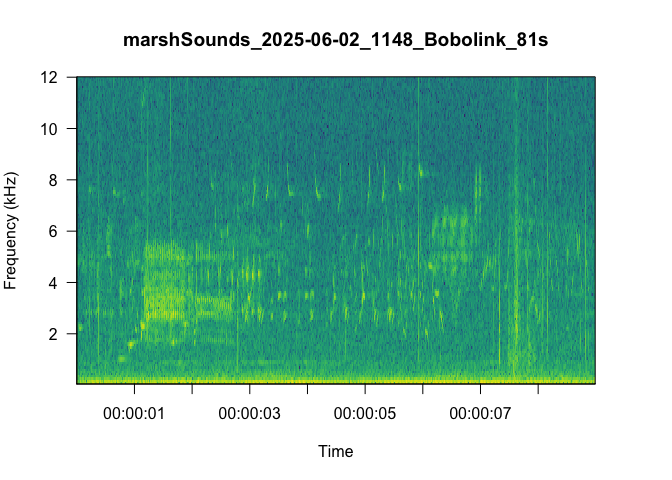

This workflow includes an option to have a Wave class object for each clip (named by original file, predicted English name, and the time the vocalization starts within the original file) and to save the .wav file of each clip for listening done by other observers or outside of R.

And that’s it for now!

In this tutorial, we:

- Ran a multi-species classifier (BirdNet) on a sound clip
- Filtered a detection table based on species that likely occur in the region (based on eBird checklist frequency data)
- Created clips of a larger .wav file both in R and for saving in separate files for further processing or listening.

Multi-species classifiers are useful tools but still require considerable quality control and thought in how data are processed and validated. Human verification will likely remain an important part of this process, but we can greatly reduce the number of clips and complexity of workflow.

What do we do with this data? That depends on your research and monitoring goals, but you may be interested in using the processed data for:

- Summarizing which species and how many species were detected at a site to support a decision.
- Occupancy models (either for single species or multi-species, and either single season or dynamic) to estimate how species respond to environmental variation or change through time.
- Fitting other types of Species Distribution Models (SDMs) with the species data generated from multi-species classifiers and human listening.

In the next tutorial, I will cover the basics of soundscape indices in R.

Written by [James E Paterson](https://jamesepaterson.weebly.com/)